# *Notebook* sobre estudios *U&A*

L15L

Marzo 2017

# 1 Introducción

Este documento es un Notebook sobre estudios de usos y actitudes, mejor conocidos como estudios *U&A* por sus siglas en inglés.Este tipo de estudios, también denominados estudios de base, tienen como principal objetivo «entender el mercado» en términos de una correcta identificación del target. Adicionalmente buscan identificar oportunidades de crecimiento en el mercado.

Estos estudios son útiles para vincular elementos de comportamiento y opinión; por lo tanto, son estudios hechos a la medida, es decir, se elaboran dependiendo de los objetivos más relevantes. De manera general, algunos de estos objetivos son:

- Tamaño del mercado (penetración de la categoría, frecuencia de uso, etc)
- Entendimiento general de la categoría (quién, qué, cuándo, cómo, dónde consume; barreras de cosumo, motivadores de compra, etc)
- Entendimiento de marca (penetración de la marca, percepción de la marca, razones de selección de marca)
- Información para dirigir los productos (segmentos actitudinales y de comportamiento)

En particular, en el ámbito de investigación de mercados existen una serie de términos que son muy comunes. A continuación mencionaremos algunos de ellos para estar familiarizados.

# 2 Algunas definiciones

- Top of Mind awareness: es una métrica que sirve para medir la clasificación de las marcas en la mente del consumidor. El Top of Mind en particular se refiere a la marca o producto fue surge primero en la mente del consumidor al pensar en una industria en específico. Generalmente se mide como porcentaje.
- Share of Mind awereness: A diferencia el Top of Mind, es el conjunto de marcas de una misma categoría de productos que el consumidor tiene en su mente. En este caso no importa el orden en que haya sido mencionada.
- Total awereness: El conocimiento total está compuesto por el Top of Mind (TOM) y el Share Mind (SOM), más el conocimiento ayudado (aided awareness) el cual es el conjunto de marcas que el consumidor no mencionó en el TOM ni en el SOM, pero que declara que conoce al momento de que se le muestra una tarjeta de apoyo.
- Top Box: Porcentaje de individuos que eligieron la opción más alta de una escala definida para una evaluación.
- Top Two Box: Porcentaje de individuos que eligieron las dos opciones más altas de una escala definida para una evaluación.
- Bottom Box: Porcentaje de individuos que eligieron la opción más baja de una escala definida para una evaluación.
- Top Two Box: Porcentaje de individuos que eligieron las dos opciones más bajas de una escala definida para una evaluación.

Ejemplo:

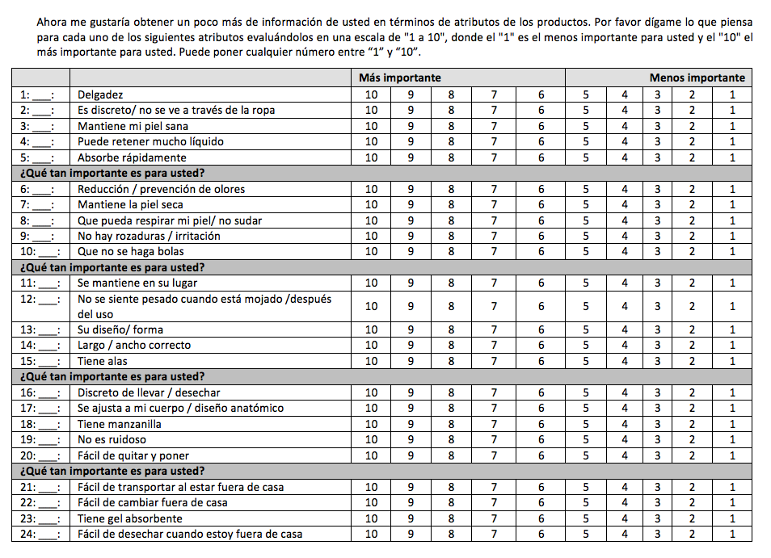

En este caso, para calcular el Top Box, debemos contar a todas las personas que elegieron la calificación 10 en cada atributo y divirlos entre el total de indivudios, de manera que se obtenga una proporción. Para el caso del Top Two Box, se deben considerar las calificaciones 10 y 9.

- Perfiles: Cuando tenemos una matriz de doble entrada, es posible determinar si existen diferencias significativas entre el cruce de los diferentes niveles de las dos variables. Para encontrar estas diferencias, utilizamos los perfiles que son una técnica que permite crear un índice con respecto al promedio de las observaciones. Así, todo aquello que sobresalga por arriba del promedio se reconocerá como sobre indexado y significativamente mayor. De manera análoga, todo aquello que se encuentre por debajo del promedio, se denominará sub indexado y significativamente menor.

Consideremos el siguiente ejemplo:

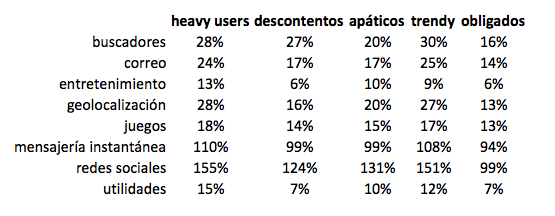

En la tabla anterior se tienen en las columnas grupos o segmentos obtenidos a partir de la actitud de los individuos hacia la telefonía celular. Por ejemplo, los heavy users son aquellos individuos que utilizan con mucha frecuencia el celular y siempre están «conectados», mientras que los obligados son aquellos que usan el celular por necesidad. En las filas se tienen agrupaciones de *apps* de acuerdo a su función. Por ejemplo *WhatsApp* se encuentra en la categoría mensajería instantánea, mientras que *Facebook* y *Twitter* se encuentran en redes sociales.

Lo que reportamos en la tabla es el porcentaje de *apps* que utilizan dependiendo del segmento y de la categoría de la *app*. Notemos que hay categorías con más del 100%, esto se debe a que un solo usuario puede utilizar más de una *app* de la misma categoría, i.e., si utiliza tanto *Facebook* como *Twitter* debemos contar las dos menciones. Esto se denomina comúnmente respuesta múltiples.

Lo que buscamos es identificar qué segmentos están, en mayor o menor medida, relacionados significativamente con las categorías de las *apps*. Para lograr lo anterior generaremos los perfiles. Los perfiles se pueden calcular a nivel renglón, a nivel columna o bien pueden ser tanto a nivel renglón y columna.

**Definición: Perfil renglón**

Sea $\mathbf{A} \in \mathcal{M}_{n\times m}(\mathbb{R})$ una matriz de $n\times m$ tal que

$${\displaystyle \mathbf {A} = {\begin{bmatrix}
a_{11} & a_{12} & \cdots & a_{1m}\\
a_{21} & a_{22} & \cdots & a_{2m} \\
\vdots & \vdots & \ddots & \vdots \\
a_{n1} & a_{n2} & \cdots & a_{nm}\\
\end{bmatrix}}}$$
y sea $r_{ij}$ el perfil renglón del $i$-ésimo renglón, definido como

$$r_{ij} = \frac{a_{ij}}{\frac{1}{m}\sum_{\forall j} a_{ij}},$$

entonces la matriz

$${\displaystyle \mathbf {PR} = {\begin{bmatrix}
r_{11} & r_{12} & \cdots & r_{1m} \\
r_{21} & r_{22} & \cdots & r_{2m} \\
\vdots & \vdots & \ddots & \vdots \\
r_{n1} & r_{n2} & \cdots & r_{nm} \\
\end{bmatrix}}}$$

se denomina la matriz de perfiles renglón.

**Definición: Perfil columna**

Sea $\mathbf{A} \in \mathcal{M}_{n\times m}(\mathbb{R})$ una matriz de $n\times m$ tal que

$${\displaystyle \mathbf {A} = {\begin{bmatrix}
a_{11} & a_{12} & \cdots & a_{1m} \\
a_{21} & a_{22} & \cdots & a_{2m} \\
\vdots & \vdots & \ddots & \vdots \\
a_{n1} & a_{n2} & \cdots & a_{nm} \\
\end{bmatrix}}}$$
y sea $c_{ij}$ el perfil columna de la $j$-ésima columna, definido como

$$r_{ij} = \frac{a_{ij}}{\frac{1}{n}\sum_{\forall i} a_{ij}},$$

entonces la matriz

$${\displaystyle \mathbf {PC} = {\begin{bmatrix}
c_{11} & c_{12} & \cdots & c_{1m}\\
c_{21} & c_{22} & \cdots & c_{2m} \\
\vdots & \vdots & \ddots & \vdots \\
c_{n1} & c_{n2} & \cdots & c_{nm}\\
\end{bmatrix}}}$$

se denomina la matriz de perfiles columna.

**Definición: Perfiles dobles**

Sea $\mathbf{A} \in \mathcal{M}_{n\times m}(\mathbb{R})$ una matriz de $n\times m$ y sea $\mathbf{PC} \in \mathcal{M}_{n\times m}(\mathbb{R})$ la matriz de perfiles renglón correspondiente, entonces si aplicamos perfiles columna a $\mathbf{PC}$, tenemos que

$${\displaystyle \mathbf {PD} = {\begin{bmatrix}
d_{11} & d_{12} & \cdots & d_{1m}\\
d_{21} & d_{22} & \cdots & d_{2m} \\
\vdots & \vdots & \ddots & \vdots \\
d_{n1} & d_{n2} & \cdots & d_{nm}\\
\end{bmatrix}}}$$

donde $\mathbf{PD}$ se denomina matriz de perfiles dobles.

**Observaciones**

- Los perfiles renglón son útiles cuando se desea hacer la comparación entre de cada renglón de manera independiente con respecto a todas las columnas. En nuestro ejemplo, el perfil renglón nos ayuda a identificar qué segmentos resaltan de acuerdo a la categoría de *apps*. Notemos que en la siguiente imagen se colorean los perfiles. De color negro se encuentran los perfiles sobre indexados, de color gris los perfiles que se encuentran en un rango promedio y de color rojo los perfiles sub indexados o por debajo del promedio. Estos perfiles utilizaron la regla 110 - 90, que es la más común. Esto significa que valor por arriba de 110 son coloreados de negro, entre 110 y 90n de gris y menores a 90 de rojo. La regla de coloreado puede modificarse de acuerdo a las necesidades, cuando las diferencias no son muy claras se puede reducir el intervalo a 105 - 95. Por el contrario, cuando el tamaño de muestra es pequeño, se puede utilizar un intervalo más amplio, 120 - 80, para evitar «identificar» diferencias que no son realmente significativas. En este caso, ¿qué diferencias identificas?

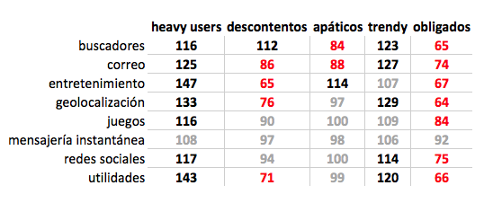

- Los perfiles columna son útiles cuando se desea hacer la comparación entre de cada columna de manera independiente con respecto a todos los renglones. En nuestro ejemplo, notamos que los perfiles columna no poco útiles pues las categorías mensajería instantánea y redes sociales tienen una multiplicidad muy alta. Adicional a lo anterior, observemos que este comportamiento ocurre en todos los segmentos.

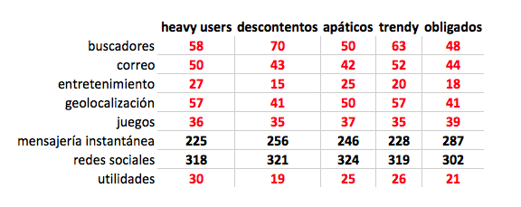

- Los perfiles dobles son útiles cuando se desea hacer la comparación de todos los renglones y todas las columnas. Este perfilamiento nos permite identificar diferencias significativas entre todos los niveles y ambas variables. También ayudan a quitar el efecto de respaldos muy pequeños o muy grandes. En el ejemplo, notemos que los perfiles son más útiles pues permiten identificar a los segmentos que utilizan más o menos cierto tipo de *apps*, independientemente de la multiplicidad de *apps* en la categoría. En los perfiles columna las redes sociales aparantemente sobresalen con respecto a las demás, sin embargo cuando hacemos la comparación entre los segmentos (perfil doble), notamos que no hay diferencias significativas.

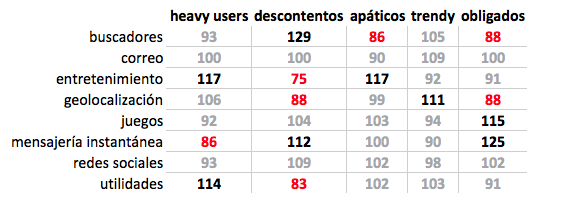

# 3 Tipos de análisis *U&A*

A continuación mencionaremos algunos de los análisis que comprenden los estudios *U&A* que realizamos con mayor frecuencia en L15L.

## 3.1 Conversiones

Las conversiones son una herramienta utilizada en la investigación de mercados cuyo objetivo principal es evaluar el desempeño de las marcas dentro de una categoría, realizando una comparación «justa» en términos de conocimiento de marca, consumo y uso.

Generalmente, para evaluar lo anterior se realizan preguntas de conocimiento: conocimiento espontáneo y ayudado, hábitos de consumo (marcas que compra con más frecuencia, que ha comprado alguna vez o que nunca compraría) y hábitos de uso (marcas utilizadas con mayor frecuencia, que ha usado alguna vez o que nunca usaría). Una batería típica para análisis de conversiones es la siguiente

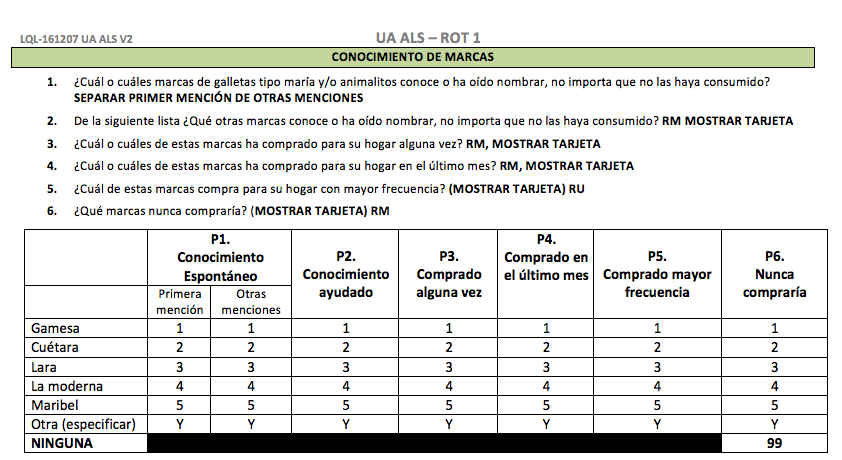

Para ejemplificar este tipo de análisis utilizaremos la información de un estudio de galletas.

```r
source("helpers.R")
base.conversiones <- readRDS(file = "base_conversiones.RDS")

base.conversiones %>%
  head(9)
```

```
##   folio      marca       conversion
## 1     1     Gamesa  primera.mencion
## 2     1    Cuétara       espontaneo
## 3     1       Lara          ayudado
## 4     1 La moderna          ayudado
## 5     1     Gamesa       alguna.vez
## 6     1       Lara       alguna.vez
## 7     1     Gamesa       ultimo.mes
## 8     1       Lara       ultimo.mes
## 9     1     Gamesa mayor.frecuencia
```

La base de datos se compone de la respuesta (marca) de cada individuo a la batería de conocimiento de marcas presentada anteriormente. Notemos que la primera mención del conocimiento así como la marca consumida con mayor frecuencia son respuestas únicas, todas las demás son respuesta múltiple.

Así mismo la marca favorita y la marca más frecuente son respuestas únicas, mientas que marcas que ha comprado alguna vez, ha comprado en el último vez y que nunca compraría son de opción múltiple.

Para obtener las conversiones, lo que se necesita es calcular el porcentaje por marca de las diferentes variables:

- TOM
- SOM = Primera mención + Otras menciones (espontáneo todo)
- Conocimiento total = SOM + Conocimiento ayudado
- Marca más frecuente
- Comprado en el último mes
- Comprado alguna vez

Lo único que debemos cuidar es si la respuesta es única o si fue respuesta múltiple, en caso de ser respuesta múltiple debemos considerar la base entre la cual se calculará el porcentaje. Comencemos con este ejemplo

```r
tom <- base.conversiones %>%
  dplyr::filter(conversion == "primera.mencion") %>%
  group_by(marca) %>%
  tally %>%
  data.frame %>%
  mutate(tom = n/n_distinct(base.conversiones$folio)*100) %>%
  dplyr::select(-n)

som <- base.conversiones %>%
  dplyr::filter(conversion %in% c("primera.mencion", "espontaneo")) %>%
  group_by(marca) %>%
  tally %>%
  data.frame %>%
  mutate(som = n/n_distinct(base.conversiones$folio)*100) %>%
  dplyr::select(-n) %>%
  dplyr::filter(marca != "Ninguna")

total <- base.conversiones %>%
  dplyr::filter(conversion %in% c("primera.mencion", "espontaneo", "ayudado")) %>%
  group_by(marca) %>%
  tally %>%
  data.frame %>%
  mutate(total = n/n_distinct(base.conversiones$folio)*100) %>%
  dplyr::select(-n) %>%
  dplyr::filter(marca != "Ninguna", marca != "NInguna")

mayor.frec <- base.conversiones %>%
  dplyr::filter(conversion == "mayor.frecuencia") %>%
  group_by(marca) %>%
  tally %>%
  data.frame %>%
  mutate(mayor.frec = n/n_distinct(base.conversiones$folio)*100) %>%
  dplyr::select(-n)

alguna.vez <- base.conversiones %>%
  dplyr::filter(conversion == "alguna.vez") %>%
  group_by(marca) %>%
  tally %>%
  data.frame %>%
  mutate(alguna.vez = n/n_distinct(base.conversiones$folio)*100) %>%
  dplyr::select(-n)

ultimo.mes <- base.conversiones %>%
  dplyr::filter(conversion == "ultimo.mes") %>%
  group_by(marca) %>%
  tally %>%
  data.frame %>%
  mutate(ultimo.mes = n/n_distinct(base.conversiones$folio)*100) %>%
  dplyr::select(-n)


(conversiones <- total %>%
  left_join(tom) %>%
  left_join(som) %>%
  left_join(alguna.vez) %>%
  left_join(ultimo.mes) %>%
  left_join(mayor.frec) %>%
  gather(variable, valor, -marca) %>%
  dplyr::filter(!is.na(valor)) %>%
  spread(variable, valor, fill = 0))
```

```
##         marca alguna.vez mayor.frec        som        tom       total
## 1       Copsa  0.0000000   0.000000  0.3838772  0.0000000   0.3838772
## 2     Cuétara 49.5201536  10.172745 45.8733205 12.4760077  91.3627639
## 3       Donde  3.6468330   1.343570  4.0307102  1.1516315   4.0307102
## 4     Doradas  0.0000000   0.000000  0.3838772  0.1919386   0.3838772
## 5      Gamesa 93.2821497  79.654511 92.7063340 68.7140115 100.0000000
## 6  La moderna 21.6890595   1.343570 22.0729367  4.9904031  61.8042226
## 7        Lara 44.7216891   7.485605 46.2571977 11.5163148  94.0499040
## 8      Mac Ma  0.1919386   0.000000  0.1919386  0.0000000   0.1919386
## 9  Marias s/e  0.0000000   0.000000  0.1919386  0.1919386   0.1919386
## 10    Maribel  3.8387716   0.000000  8.0614203  0.7677543  19.0019194
## 11   Marinela  0.1919386   0.000000  0.7677543  0.0000000   0.7677543
##    ultimo.mes
## 1    0.000000
## 2   23.608445
## 3    2.879079
## 4    0.000000
## 5   86.372361
## 6    9.213052
## 7   20.345489
## 8    0.000000
## 9    0.000000
## 10   1.535509
## 11   0.000000
```

Ahora, una vez que contamos con la base de datos con la información sobre conocimiento de marca y consumo lo que buscamos es entender el comportamiento de las marcas de acuerdo a la siguiente línea de pensamiento:

- ¿Qué es lo primero que buscamos cuando lanzamos un producto al mercado? Que al menos el consumidor compre nuestro producto, lo que nos lleva a la variable *comprado alguna vez*
- Dado que ya sabemos que nos ha comprado alguna vez, ¿consumió nuestro producto en el último mes? Aquí depende mucho de la categoría de producto, porque si hablamos de autos, por ejemplo, sabemos que la frecuencia de consumo no es tan regular (i.e., normalmente la gente no compra un auto nuevo cada mes). La idea es establecer una frecuencia de consumo de acuerdo a la categoría que sea razonable para la comparación
- Si ya sabemos que nuestra marca está dentro de las marcas que consume frecuentemente, entonces es razonable considerar que somos una marca que conoce. ¿Qué tanto nos conoce? ¿Somos la primera marca que menciona que conoce?
- Si estamos dentro de las marcas que más consume, ¿somos la marca más frecuente?. Si somos la marca más frecuente, ¿somos la primera marca que menciona?

Cabe resaltar que hay ciertas categorías de producto en la cual la marca más conocida no necesariamente es la más frecuente. Pensemos, en marca de celulares, todos conocen las marcas Apple o Samsung, pero no necesariamente todos tienen un iPhone o un Galaxy.

En general las conversiones buscan conocer en qué etapa (proceso de cambio/conversión) de las mencionadas anteriormente se ubica la marca o marcas de interés.

Existen diferentes formas de presentar el análisis de conversiones, en particular, en L15L lo que se hace es construir mapas que muestren la posición de diferentes marcas en cada una de las etapas:

1. Alguna vez vs último mes
2. Último mes vs más frecuente
3. Más frecuente vs conocimiento total
4. Conocimiento total vs alguna vez
5. Conocimiento total vs conocimiento espontáneo (SOM)
6. Conocimiento espontáneo (SOM) vs primera mención (TOM)

Los mapas consisten en plasmar en un plano de dimensión 2 las coordenadas de cada marca respecto a las variables con respecto a las cuales se desea hacer el análisis. Además de mostrar los puntos, se ajusta una curva suave (polinomio de grado 2) para identificar la tendencia.

A continuación haremos algunos ejemplos

**Conversiones alguna vez vs último mes**

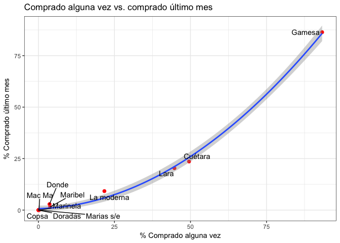

```r
library(ggrepel)

conversiones %>%
  dplyr::select(marca, alguna.vez, ultimo.mes) %>%
  ggplot(aes(x = alguna.vez, y = ultimo.mes)) +
  geom_point(size = 2, col = "red") +
  geom_smooth(method = "lm", formula = y ~ poly(x, 2, raw = TRUE)) +
  geom_text_repel(aes(label = marca)) +
  labs(title = "Comprado alguna vez vs. comprado último mes",
       x = "% Comprado alguna vez",
       y = "% Comprado último mes")
```

**Conversiones último mes vs más frecuente**

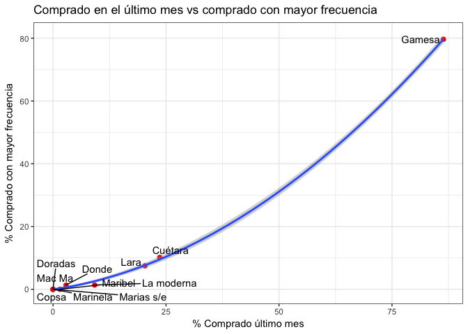

```r
conversiones %>%
  dplyr::select(marca, ultimo.mes, mayor.frec) %>%
  ggplot(aes(x = ultimo.mes, y = mayor.frec)) +
  geom_point(size = 2, col = "red") +
  geom_smooth(method = "lm", formula = y ~ poly(x, 2, raw = TRUE)) +
  geom_text_repel(aes(label = marca)) +
  labs(title = "Comprado en el último mes vs comprado con mayor frecuencia",
       x = "% Comprado último mes",
       y = "% Comprado con mayor frecuencia")
```

**Conocimiento total vs SOM**

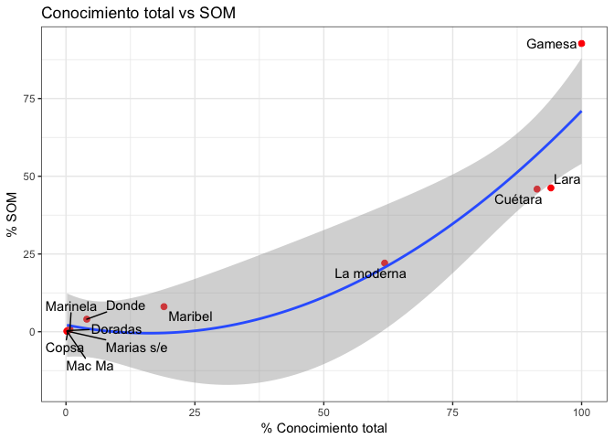

```r
conversiones %>%
  dplyr::select(marca, total, som) %>%
  ggplot(aes(x = total, y = som)) +
  geom_point(size = 2, col = "red") +
  geom_smooth(method = "lm", formula = y ~ poly(x, 2, raw = TRUE)) +
  geom_text_repel(aes(label = marca)) +
  labs(title = "Conocimiento total vs SOM",
       x = "% Conocimiento total",
       y = "% SOM")
```

**SOM vs TOM**

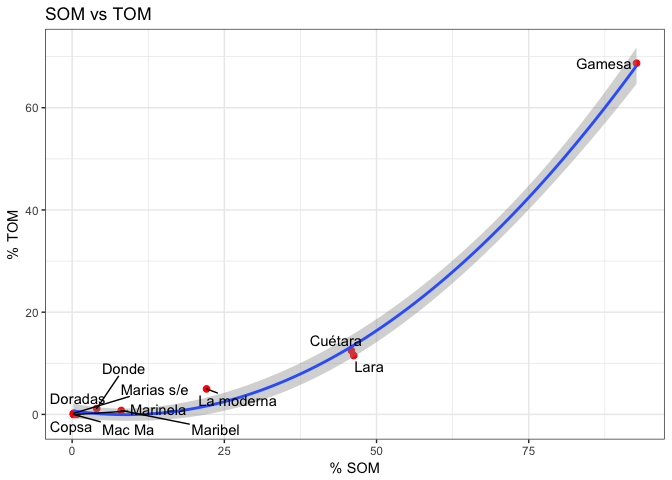

```r
conversiones %>%
  dplyr::select(marca, som, tom) %>%
  ggplot(aes(x = som, y = tom)) +
  geom_point(size = 2, col = "red") +
  geom_smooth(method = "lm", formula = y ~ poly(x, 2, raw = TRUE)) +
  geom_text_repel(aes(label = marca)) +
  labs(title = "SOM vs TOM",
       x = "% SOM",
       y = "% TOM")
```

## 3.2 Biplots de imagen

Los biplots son gráficos empleados comúnmente para el análisis exploratorio. Son representaciones gráficas que mapean $n$ variables en un plano cartesiano.

En L15L, utilizamos los biplots para representar gráficamente matrices de datos con información de diferentes fuentes. En particular, en estudios de mercado es de interés conocer la imagen o percepción de la gente hacia cierta marca, producto o categoría. Los biplots de imagen nos permiten asociar tanto atributos positivos (motivadores) como negativos (barreras) a ciertas marcas o productos.

Una metodología para construir biplots es el análisis de componentes principales. El análisis de componentes principales, PCA por sus siglas en inglés, permite proyectar un cojunto de datos en un espacio de menor dimensión. La idea principal es transformar un número considerable de variables posiblemente correlacionadas en un número menor de variables no correlacionadas (ortogonales), denominadas componentes principales. Así, mediante dichas componentes, es posible representar la información de $n$ variables y $j$ individuos en espacios de dimensión $k$ con $k\leq n$. En particular si $k=2$ tendríamos una proyección de los datos en un plano y, por consiguiente, un biplot.

**Nota:** El análisis de componentes principales no es trivial y existen varios aspectos que se deben cuidar, entre ellos el porcentaje de varianza explicado. Para profundizar sobre el tema, se recomienda revisar el Notebook sobre Segmentación.

Ejemplo:

En un estudio para una compañía de telefonía móvil, se desea conocer la imagen de los diferentes carriers o proveedores de servicio de acuerdo al mercado. Para ello, se hizo la siguiente pregunta

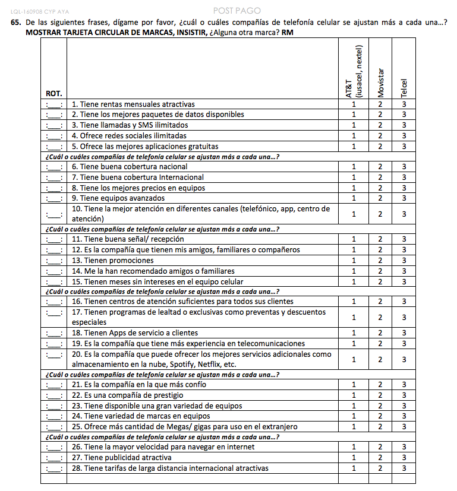

A partir de esta batería de preguntas, podemos generar un biplot en el cual se asocien los atributos que más relacionados están con los tres diferentes carriers. Para lograr lo anterior, necesitamos contruir una matriz de datos con el porcentaje de menciones que tuvo cada atributo en cada carrier.

Primero contamos las menciones que tuvo cada carrier en cada atributo, notemos que esta es una pregunta de opción múltiple, es decir que un individuo puede asignar a más de un carrier el mismo atributo.

```r
data.biplot <- readRDS("data.biplot.RDS")

data.biplot %>%
  arrange(desc.corta) %>%
  head
```

```
## # A tibble: 6 x 4
##                        desc.corta `AT&T` Movistar Telcel
##                            <fctr>  <int>    <int>  <int>
## 1     Apps de servicio a clientes   1428     1432   1682
## 2   Buena cobertura internacional   1526     1339   1758
## 3        Buena cobertura nacional   1609     1389   1821
## 4                     Buena señal   1630     1350   1715
## 5 Centros de atención suficientes   1468     1406   1698
## 6    Compañía con más experiencia   1341     1409   1640
```

Luego obtenemos los porcentajes que recibió cada carrier en cada atributo, estos porcentajes son conocidos también como respaldos. Para hacer esto es necesario tomar en cuenta la base (tamaño de muestra) adecuada. En este caso se realizaron 3072 entrevistas, por lo tanto,

```r
base.estudio <- 3072

respaldos <- data.biplot %>%
  gather(variable, value, -desc.corta) %>%
  mutate(respaldo = value/base.estudio) %>%
  dplyr::select(-value) %>%
  spread(variable, respaldo)

respaldos %>% head
```

```
## # A tibble: 6 x 4
##                        desc.corta    `AT&T`  Movistar    Telcel
##                            <fctr>     <dbl>     <dbl>     <dbl>
## 1     Apps de servicio a clientes 0.4648438 0.4661458 0.5475260
## 2   Buena cobertura internacional 0.4967448 0.4358724 0.5722656
## 3        Buena cobertura nacional 0.5237630 0.4521484 0.5927734
## 4                     Buena señal 0.5305990 0.4394531 0.5582682
## 5 Centros de atención suficientes 0.4778646 0.4576823 0.5527344
## 6    Compañía con más experiencia 0.4365234 0.4586589 0.5338542
```

A partir de este *dataframe*, el cual contiene los respaldos de los atributos, se calculan los perfiles para construir el biplot. Notemos que los perfiles proveerán diferente información dependiendo del tipo de perfil que se utilice. Por ejemplo, si utilizamos perfil renglón comparamos cada atributo entre todos los carriers. Por otro lado, si utilizamos perfil columna comparamos todos los atributos dentro de cada carrier.

De esta forma, si utilizamos perfiles dobles comparamos todos los atributos contra todos los carriers. Generalmente, los perfiles dobles son los más utilizados para realizar los biplots ya que resaltan los atributos que están por arriba y por abajo del promedio al comparar ambas variables.

Antes de construir el biplot es importante cerciorarse qué tipo de perfiles son los adecuados para el análisis. Esto estará en función de lo que se requiera resaltar en el estudio. En general, los perfiles dobles son los más utilizados, sin embargo no es una regla determinada.

En este ejemplo, utilizaremos los perfiles dobles pues buscamos resaltar aquellos atributos que se distinguen en cada carrier para poder hacer las asociaciones correspondientes. Una vez que obtenemos la matriz perfilada, le aplicamos PCA y con la función *biplot_atributos* creamos la gráfica:

```r
library(FactoMineR)

respaldo.perfilados <- respaldos %>%
  perfilesDobles
```

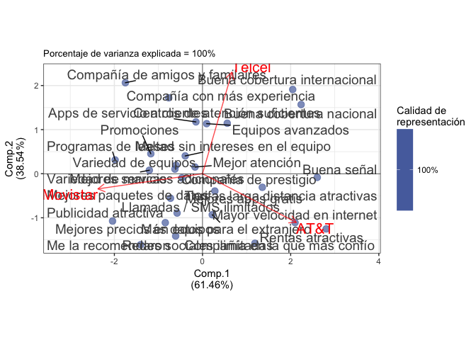

```r
comp <- PCA(respaldo.perfilados, graph = F)

biplot_atributos(PC = comp)
```

Un aspecto importante del biplot es que siempre va acompañado de la matriz perfilada que lo generó. De hecho, parte de la salida que se entrega en un análisis de biplot es la matriz perfilada coloreada y el mapa como tal. Este mapa que vemos contiene ejes y el porcentaje de varianza, esta versión es para el equipo de análisis. La función *biplot_atributos* tiene la opción de cambiar el formato en la versión de reporte, el cual luce así

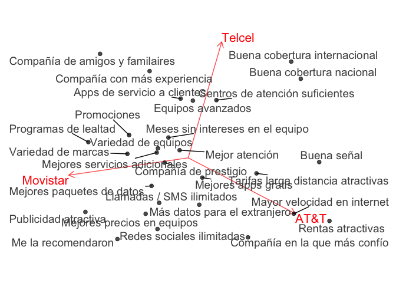

```r
biplot_atributos(PC = comp, format = "report")
```

**Interpretación**

Una vez que hemos generado el biplot, debemos revisar los resultados que este nos brinda. Algunos aspectos importantes que se deben cuidar son

- **Porcentaje de varianza explicado:** El biplot, al estar construido a partir de las componentes principales, debe reflejar un porcentaje de varianza razonable. Por ello, debemos tomar en cuenta el total de varianza explicado por las dos componentes. Recordemos que la primera componente explica un porcentaje de varianza mayor que la siguiente componente y así sucesivamente.
- **Dispersión de los atributos:** Al momento de mapear los puntos (en este caso los atributos), mientras más dispersos se encuentren mayor es la discriminación o diferencia entre ellos. Esto es un indicador de que realmente existen diferencias significativas en los atributos. Por el contrario, si los puntos se encuentran muy cercanos al origen y apiñados entonces estamos observando que los atributos no se diferencian entre ellos. Idealmente deseas poder identificar y diferenciar los atributos.
- **Tamaño de las flechas:** Las flechas que componen el biplot son los scores de las componentes y representan la asociación de estos con los atributos mapeados en el plano. Las flechas nos representan la dirección y el sentido en el cual, en este caso los carriers, se relacionan con los atributos. Mientras mayor sea la longitud de la flecha, más fuerte la relación con el/los atributo(s) asociados. Por otro lado, mientras menor sea la longitud la relación es menor.

Finalmente, y en vista de que los biplots nos proveen información descriptiva de los datos, debemos proceder a analizar el mapa y corroborar que los resultados obtenidos tienen sentido. En este ejemplo notamos que Telcel es un carrier asociado con atributos de cobertura, lo cual hace sentido ya que este carrier está muy bien consolidado en el mercado y además ha logrado una campaña muy exitosa con respecto a la cobertura que ofrecen. Por otro lado AT&T, que es un carrier nuevo en el mercado mexicano, está relacionado con atributos de oferta más atractiva. Para reforzar el análisis del mapa, es necesario utilizar también la matriz de perfiles que lo generó, para sustentar con más argumentos los resultados obtenidos.

## 3.3 Mapas de imagen

Los mapas de imagen son herramientas gráficas útiles que permiten ubicar y asociar diferentes marcas de una misma categoría con atributos de imagen. Para entender mejor la función de estos mapas, definiremos algunos conceptos propios de la herramienta:

- **Importancias declaradas** Es el porcentaje en top box o en top two box de cada atributo obtenidos de una bateria de imagen. El criterio para determinar si se utiliza top box o top two box consiste en elegir a aquel que discrimine más, es decir, que refleje mayores diferencias entre los porcentajes de los respaldos (el que tenga mayor dispersión).
- **Importancias implícitas** Es el porcentaje en top box o en top two box de cada atributo asignado filtrado según los siguientes criterios:
  - Si el objetivo del estudio es evaluar la imagen general se calculan las importancias con respecto a la marca favorita o bien la que se compra con mayor frecuencia, dependiendo de lo que se haya preguntado.
  - Si el objetivo del estudio es evaluar la imagen de marcas de manera específica, entonces se calculan las importancias con respecto a la marca que utiliza.
- **Atribución a la marca** Es el respaldo o porcentaje de menciones que recibió cada marca en los diferentes atributos. En este caso se considera el respaldo a total muestra para todas las marcas, es decir, todos los individuos realizan la evalución para todas las marcas.

### 3.3.1 Mapa de importancias

Este mapa consiste en ubicar en un plano cartesiano las importancias implícitas y las importancias declaradas. De manera general, las importancias declaradas representan aquello que los consumidores, en primera instancia, identifican como relevante en la categoría. Sin embargo no necesariamente todo lo que el consumidor declara como importante de manera directa es lo que más aprecia. Las importancias implícitas justamente buscan encontrar aquello que los consumidores más aprecian, vía la evaluación que hacen de su marca favorita/más consumida/actual.

Estos mapas son representaciones gráficas que permiten ubicar a todos los atributos en un plano cartesiano, de manera que se clasifiquen en:

- Oportunidades
- Fortalezas
- Objetivos logrados

Para generar los mapas de importancias necesitamos generar una matriz que contenga tantos renglones como atributos y dos columnas, una para las importancias declaradas y ota para las importancias implícitas. El mapa de importancias cosiste simplemente en ubicar cada atributo tomando como coordenadas las importancias. Las declaradas se toman como las abscisas y las implícitas como las ordenadas. A continuación veremos un ejemplo utilizando nuevamente la información del estudio de telefonía móvil.

Para obtener las importancias declaradas, considere la siguiente batería

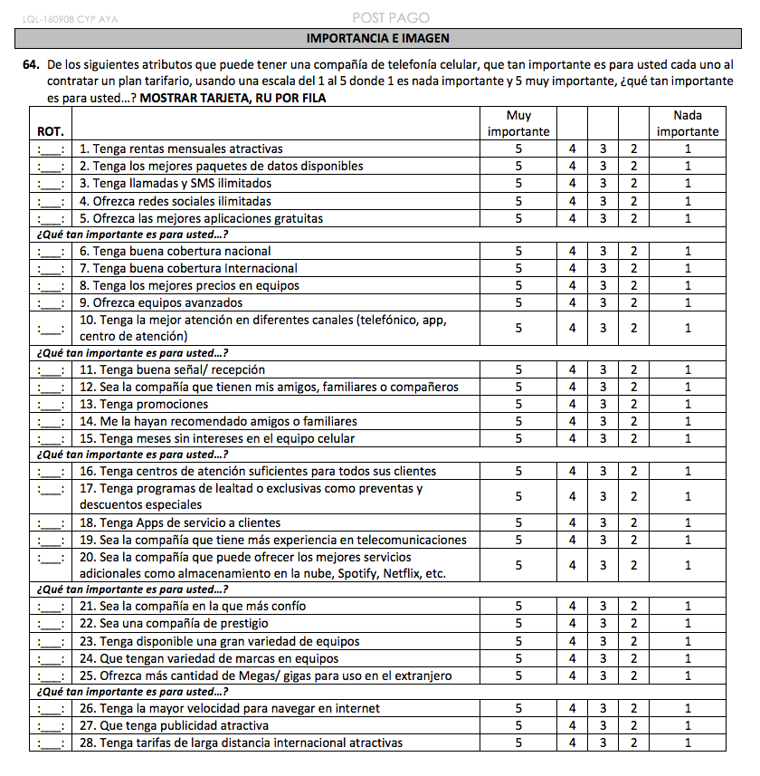

Luego, para calcular las importancias declaradas obtenemos el porcentaje tb y t2b de cada atributo, i.e,

```r
base.declaradas <- readRDS('base.declaradas.RDS')
atributos <- readRDS('atributos_imagen.RDS')

base.declaradas %>% head
```

```
##   folio          p64.a          p64.b          p64.c          p64.d
## 1     1 Muy importante Muy importante Muy importante Muy importante
## 2     2              4              4 Muy importante              4
## 3     3 Muy importante Muy importante Muy importante              3
## 4     4 Muy importante              4 Muy importante Muy importante
## 5     5 Muy importante Muy importante Muy importante Muy importante
## 6     6 Muy importante Muy importante              4 Muy importante
##            p64.e          p64.f          p64.g          p64.h
## 1              4 Muy importante Muy importante              4
## 2              4              4 Muy importante Muy importante
## 3              4              4              3              4
## 4 Muy importante              4 Muy importante              4
## 5              4 Muy importante              4              3
## 6              4 Muy importante Muy importante              4
##            p64.i          p64.j          p64.k          p64.l
```

[output cut: 34 more lines]

```r
n_base <- n_distinct(base.declaradas %>% dplyr::select(folio))

imp.declaradas <- base.declaradas %>%
  gather(variable, value, -folio) %>%
  separate(variable, c("dum", "atr"), sep = "\\.") %>%
  mutate(tb = ifelse(value == "Muy importante", 1, 0),
         t2b = ifelse(value == "Muy importante" | value == "4", 1, 0)) %>%
  dplyr::select(-value, -dum) %>%
  group_by(atr) %>%
  summarise(frec.tb = sum(tb),
            frec.t2b = sum(t2b)) %>%
  data.frame %>%
  left_join(atributos) %>%
  mutate(porc.tb = frec.tb/n_base*100,
         porc.t2b = frec.t2b/n_base*100) %>%
  dplyr::select(desc.corta, porc.tb, porc.t2b) %>%
  arrange(desc(porc.tb))
imp.declaradas %>% summary
```

```
##                            desc.corta    porc.tb         porc.t2b
##  Apps de servicio a clientes    : 1   Min.   :33.89   Min.   :71.61
##  Buena cobertura internacional  : 1   1st Qu.:41.07   1st Qu.:81.13
##  Buena cobertura nacional       : 1   Median :43.20   Median :82.41
##  Buena señal                    : 1   Mean   :47.35   Mean   :83.81
##  Centros de atención suficientes: 1   3rd Qu.:53.77   3rd Qu.:87.82
##  Compañía con más experiencia   : 1   Max.   :69.40   Max.   :94.30
##  (Other)                        :22
```

```r
imp.declaradas %>% dplyr::select(porc.tb) %>% var
```

```
##         porc.tb
## porc.tb 80.9992
```

```r
imp.declaradas %>% dplyr::select(porc.t2b) %>% var
```

```
##          porc.t2b
## porc.t2b 27.12866
```

Notemos que el top box es la métrica con mayor variación y por lo cual la que deberíamos de utilizar para las importancias declaradas.

Para obtener las importancias implícitas, considere la siguiente batería

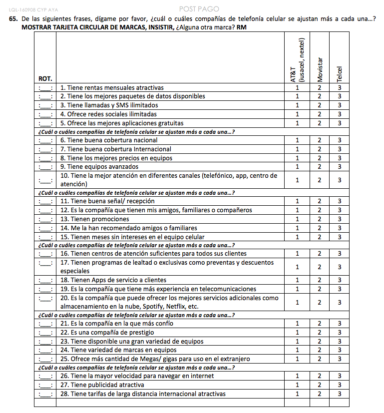

Notemos que es la misma batería con la cual generamos el biplot. Ahora, para las importancias implícitas necesitaremos anclar esta batería con la marca favorita/que más consume/marca actual. Como este estudio es un estudio enfocado en ciertas marcas específica, las importancias implícitas estarán en función del carrier (marca) actual. Para ello, primero obtendremos el carrier actual de cada individuo, y únicamente para ese carrier leemos la información de la batería. Notemos que si existe la posibilidad de responder «Ninguno» u «Otro», no debemos considerar estos casos. Únicamente para las marcas específicas.

```r
load('carrier_actual.RData')
load('base_implicitas.RData')

n_carrier <- base_implicitas %>%
  gather(variable, valor, -folio) %>%
  dplyr::filter(!is.na(valor), valor != "Ninguno") %>%
  mutate(valor = ifelse(valor == "AT&T (iusacel, nextel)", "AT&T", valor)) %>%
  arrange(folio) %>%
  left_join(carrier_actual) %>%
  dplyr::filter(valor == carrier) %>%
  dplyr::select(folio, variable, carrier) %>%
  spread(variable, carrier) %>%
  dplyr::rename(p65.aa_1 = p65a1_1, p65.aa_2 = p65a1_2, p65.aa_3 = p65a1_3,
                p65.bb_1 = p65b1_1, p65.bb_2 = p65b1_2, p65.bb_3 = p65b1_3) %>%
  gather(variable, carrier, -folio) %>%
  dplyr::filter(!is.na(carrier)) %>%
  arrange(folio) %>%
  separate(variable, c("preg", "dum1"), sep = "\\.") %>%
  separate(dum1, c("atr", "dum2"), sep = "_") %>%
  left_join(atributos) %>%
  dplyr::select(folio, carrier) %>%
  group_by(carrier) %>%
  summarise(n_carrier = n_distinct(folio))
imp.implicitas <- base_implicitas %>%
  gather(variable, valor, -folio) %>%
  dplyr::filter(!is.na(valor), valor != "Ninguno") %>%
  mutate(valor = ifelse(valor == "AT&T (iusacel, nextel)", "AT&T", valor)) %>%
  arrange(folio) %>%
  left_join(carrier_actual) %>%
  dplyr::filter(valor == carrier) %>%
  dplyr::select(folio, variable, carrier) %>%
  spread(variable, carrier) %>%
  dplyr::rename(p65.aa_1 = p65a1_1, p65.aa_2 = p65a1_2, p65.aa_3 = p65a1_3,
                p65.bb_1 = p65b1_1, p65.bb_2 = p65b1_2, p65.bb_3 = p65b1_3) %>%
  gather(variable, carrier, -folio) %>%
  dplyr::filter(!is.na(carrier)) %>%
  arrange(folio) %>%
  separate(variable, c("preg", "dum1"), sep = "\\.") %>%
  separate(dum1, c("atr", "dum2"), sep = "_") %>%
  left_join(atributos) %>%
  dplyr::select(folio, carrier, desc.corta) %>%
  group_by(carrier, desc.corta) %>%
  tally %>%
  data.frame %>%
  left_join(n_carrier) %>%
  mutate(imp.implicitas = n/n_carrier*100) %>%
  dplyr::select(carrier, desc.corta, imp.implicitas) %>%
  spread(carrier, imp.implicitas, fill = 0)
importancias <- imp.implicitas %>%
  left_join(imp.declaradas %>% dplyr::select(desc.corta, porc.tb)) %>%
  gather(carrier, implicitas, -c(desc.corta, porc.tb)) %>%
  rename(declaradas.tb = porc.tb)
```

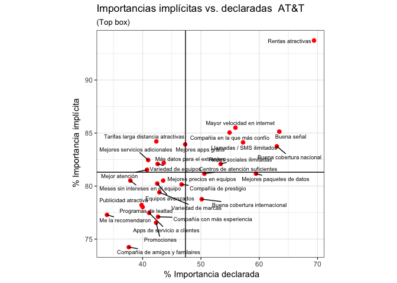

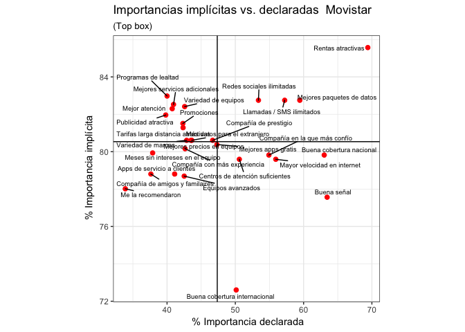

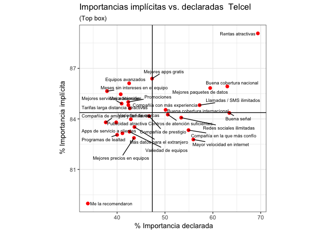

```r
mapas_importancias <- function(k){

  importancias %>%
  filter(carrier == k) %>%
  dplyr::select(-carrier) %>%
  ggplot(aes(x = declaradas.tb, y = implicitas)) +
  geom_point(size = 2, color = 'red') +
  geom_hline(aes(yintercept = mean(implicitas))) +
  geom_vline(aes(xintercept = mean(declaradas.tb))) +
  geom_text_repel(aes(x = declaradas.tb, y = implicitas, label = desc.corta), size = 2.5) +
  xlab(' % Importancia declarada') +
  ylab(' % Importancia implícita') +
  labs(title =  paste('Importancias implícitas vs. declaradas ', k),
        subtitle = '(Top box)') +
  theme_bw() +
  theme(aspect.ratio = 1)

}

lapply(unique(importancias$carrier),mapas_importancias)
```

**Observaciones** En algunas ocasiones es posible realizar los mapas con las importancias perfiladas (con índíces), esto es útil cuando no se aprecia una variación significativa en los mapas.

### 3.3.2 Mapa de atribución a la marca

Los mapas de atribución a la marca nos permite evaluar la importancia de cada atributo según las marcas. Estos mapas se construyen colocando la atribución a la marca en el eje de las abscisas y las importancias implícitas o declaras en el eje de las ordenadas. Usualmente se realizan con las importancias implícitas ya que estas están ancladas con la marca favorita/marca actual/marca más usada.

En este caso haremos los mapas con las importancias implícitas:

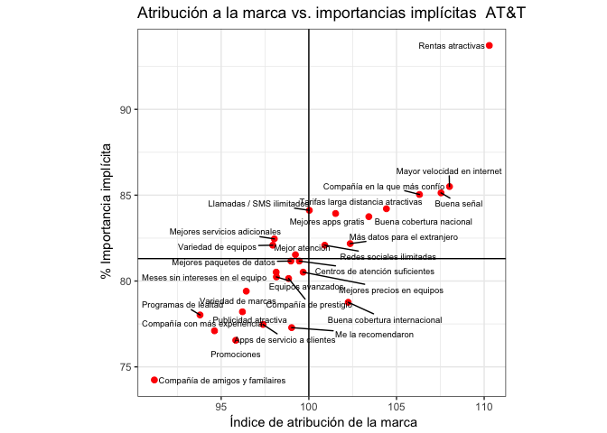

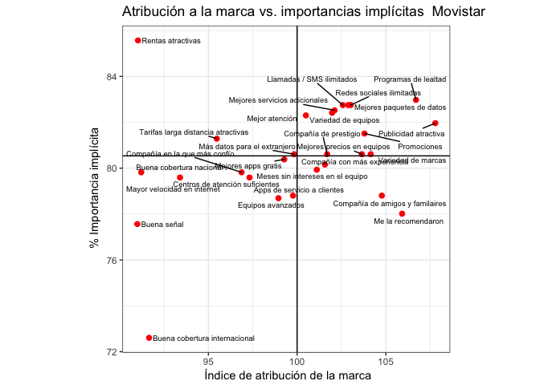

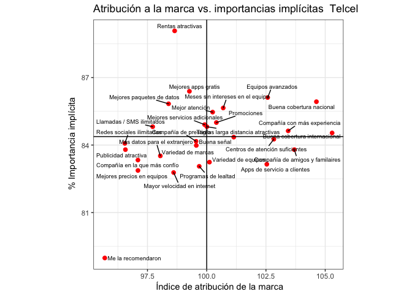

```r
atribucion.marca <- data.biplot %>%
  perfilesDobles %>%
  data.frame %>%
  rownames_to_column
names(atribucion.marca) <- c("desc.corta", "AT&T", "Movistar", "Telcel")





mapas_atribucion <- function(k){

  imp.implicitas %>%
  gather(carrier, implicitas, -desc.corta) %>%
  mutate(desc.corta = as.character(desc.corta)) %>%
  left_join(atribucion.marca %>%
              gather(carrier, atribucion, -desc.corta)) %>%
  filter(carrier == k) %>%
  dplyr::select(-carrier) %>%
  ggplot(aes(x = atribucion, y = implicitas)) +
  geom_point(size = 2, color = 'red') +
  geom_hline(aes(yintercept = mean(implicitas))) +
  geom_vline(aes(xintercept = mean(atribucion))) +
  geom_text_repel(aes(x = atribucion, y = implicitas, label = desc.corta), size = 2.5) +
  xlab(' Índice de atribución de la marca') +
  ylab(' % Importancia implícita') +
  labs(title =  paste('Atribución a la marca vs. importancias implícitas ', k)) +
  theme_bw() +
  theme(aspect.ratio = 1)

}

lapply(unique(importancias$carrier), mapas_atribucion)
```

## 3.4 Boleta informada

La boleta informada es otra ténica que se utiliza en estudios de investigación de mercados. En general, esta técnica es útil cuando se quiere evaluar la intención de compra, la satisfacción o la intención de cambio después de presentar una serie de argumentos (en escala Likert)[^1] que pueden favorecer o desfavorecer dicha intención.

La boleta informada se utiliza frecuentemente en las ciencias sociales, donde se analiza la intención de voto sobre cierto candidato antes y después de presentarle un conjunto de argumentos al encuestado. El objetivo es determinar qué argumentos tuvieron un impacto en el cambio del encuestado sobre su intención de compra, de cambio o de voto.

Usualmente, la técnica estadística empleada para una boleta informada es un modelo de regresión logístico, en el cual la variable respuesta $X_i$ es igual a 1 si el invidividuo aumentó su intención de compra después de conocer los argumentos o 0 en otro caso. Las variables independientes del modelo corresponden al valor de la pregunta asignado por el individuo en escala Likert.

Un punto a considerar es que aún cuando la escala Likert corresponde a una variable ordinal, se le da tratamiento de variable continua ya que no es posible conocer a priori la verdadera distancia entre un punto y otro. Algunas alternativas han sido propuestas, como considerar modelo polinomiales que capturen posibles efectos cuadráticos o cúbicos que no se cubren bajo el tratamiento lineal que se le da a la escala.

A continuación revisaremos un caso para ejemplificar la boleta informada. Recordemos que estamos trabajando con el caso de AT&T, unas de las inquietudes de esta empresa estadounidense es que, recién ha llegado a México cuando la escena política en términos de la relación bilateral entre estas dos naciones se ha tensado: el empresario republicano Donald Trump, quien con discursos ofensivos contra México, llega a la presidencia de los Estados Unidos. Por esta razón, AT&T desea evaluar el impacto que este hecho pueda tener en la empresa que apenas comienza a consolidarse en suelo mexicano.

Para ello, se llevó a cabo una encuesta con la siguiente estructura:

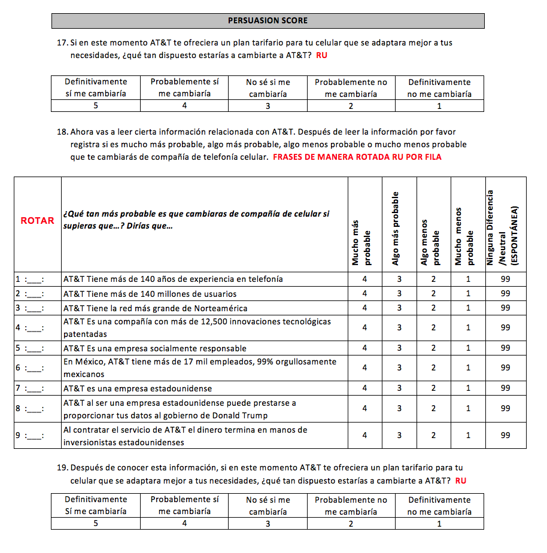

Observemos que en este caso nos interesa conocer la intención de cambio a AT&T antes y después de mostrar 9 argumentos sobre el hecho de AT&T sea una empresa estadounidense y que Trump es presidente de este país.

Para ello, definimos una nueva variable que considere el cambio que hubo en la intención. Denominaremos como *baja* si para cada individuo la intención bajó después de haber mostrado los argumentos, *igual* si no se modificó y *sube* si se incrementó. Notemos que en este caso nos interesan todos los posibles movimientos, ya que contamos con argumentos positivos como negativos. En ocasiones, sólo es de interés verificar los argumentos que conducen a un aumento (todos los argumentos son positivos). Debemos de prestar cuidado al objetivo de la boleta informada, para definir correctamente la variable respuesta.

Antes de ajustar un modelo, debemos realizar un exploratorio de los datos. Comenzaremos con una gráfica para los variables independientes, para ello utilizaremos la paquetería *likert*

```r
base.boleta <- readRDS('boleta.informada.RDS')
library(likert)
```

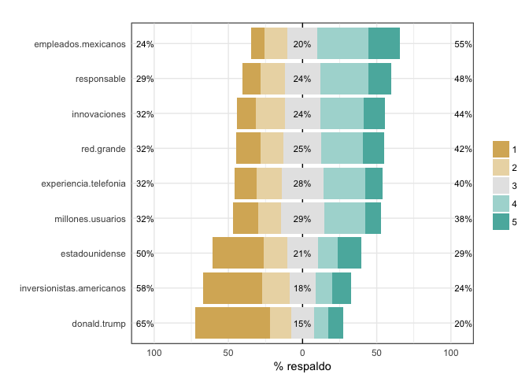

```r
base.lik <- base.boleta %>%
  dplyr::select(folio, donald.trump:responsable) %>%
  gather(variable, value, -folio) %>%
  mutate(value = factor(value)) %>%
  spread(variable, value) %>%
  dplyr::select(-folio)

lik.arnoldo <- likert(base.lik)

plot(lik.arnoldo, centered = T, legend.position = "right") +
    ylab("% respaldo") +
    theme(legend.title = element_blank()) +
    ggtitle("")
```

Esta gráfica muestra el porcentaje que se respaldó cada argumento en cada nivel de la escala Likert. Podemos observar como el argumento *AT&T al ser una empresa* *estadounidense puede prestarse a proporcionar tus datos al gobierno de Donald* *Trump* es el que más repaldo tuvo hace el nivel 1, es decir, que este argumento hace mucho menos probable que la gente se cambie a AT&T. Por otro lado, el argumento de que el 99% de los empleados de AT&T son mexicanos tuvo un 55% de respaldo hacia el hecho de que sea más mucho probable cambiarse a AT&T.

Esta gráfica nos permite identificar el comportamiento y la variabilidad de los argumentos que componen la boleta informada. Para continuar con el explotario de los datos, haremos un Ánalisis de Componentes Principales para estudiar la relación entre los atributos:

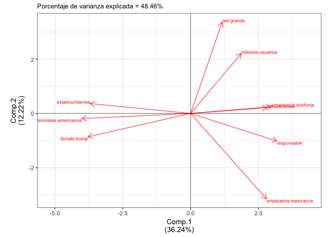

```r
base.mod <- base.boleta %>%
  mutate(respuesta = factor(ifelse(posterior > previo, "sube",
                                   ifelse(posterior < previo, "baja", "igual")))) %>%
  dplyr::select(-previo, -posterior)

aux1 <- t(scale(t(base.mod[,-c(1,11)]), scale = F))

pca <- PCA(aux1 %>% data.frame, graph = F)
biplot_atributos(pca, pts = F, var.size = 2.5)
```

Como podemos observar en este mapa, los atributos relacionados con el hecho de que AT&T es una empresa estadounidense, con inversionistas estadounidenses y que Donald Trump es el presidente de dicha nación corren en sentido opuesto a todos los otros atributos evaluados. Esto, en conjunto con la gráfica anterior, sugiere que en efecto los atributos que relacionan a AT&T con Estados Unidos y Donald Trump generar una percepción negativa en términos de la intención de cambio, sin embargo esto no garantiza que en efecto la gente deje de consumir el producto.

No obstante, notemos que la varianza explicada es apenas del 48.46%, lo cual es considerablemente bajo, por lo que las inferencias obtenidas de nuestro biplot no son tan concluyentes. A pesar del bajo porcentaje de varianza explicado, sí podemos dibujar la idea de asociación que tienen los atributos pues además es muy sensata.

Ahora, una vez que hicimos un primer análisis exploratorio de la información, debemos proceder a realizar un modelo en el cual la variable respuesta es la intención de cambio a AT&T y queremos relacionar esta variable con los argumentos que se le presentaron a los encuestados. El objetivo es evaluar si podemos establecer una relación entre estos y la intención de cambio, así como la magnitud de la misma.

Usualmente, en una boleta informada se considera un modelo logístico pues se establece como variable respuesta

$$y =
\begin{cases}
1 & \mbox{si hubo aumento en la intención} \\
0 & \mbox{en otro caso}
\end{cases}$$
de manera que se especifica un modelo lineal generalizado con liga logit.

Sin embargo, en este caso, como tenemos atributos que de cierta forma son negativos, también nos interesa la disminución en la intención. Por ello, se sugiere considerar

$$y =
\begin{cases}
1 & \mbox{si hubo disminución en la intención} \\
2 & \mbox{si no hubo cambio} \\
3 & \mbox{si hubo aumento en la intención}
\end{cases}$$

Dada esta nueva especificación, nos encontramos ahora que el modelo no es logístico pero multinomial. Por lo tanto, el ajuste debe ser distinto.

**Observación** Es crucial identificar en una boleta informada a la variable respuesta. Dependiendo del contexto y del objetivo del estudio la podemos definir como una variable binomial o multinomial.

En nuestro caso, considerando la especificación multinomial, haremos un primer análisis exploratorio pero ahora considerando si los individuos modificaron (ya sea hacia arriba, hacia abajo o si se quedó igual) su intención de cambio a AT&T.

Este cambio en la intención de cambio se obtiene comparando entre la intención de cambio inicial y la final, es decir, aquella que declaran después de que se le presentaron los atributos.

Veamos los resultados con nuestros datos

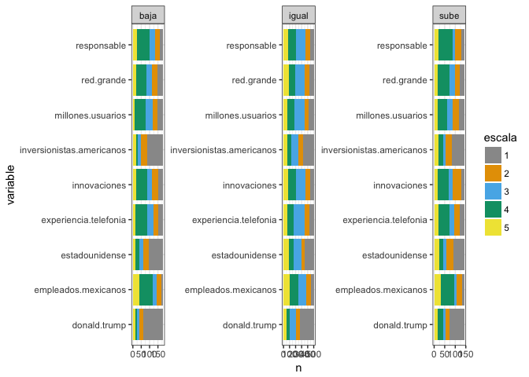

```r
base.mod %>%
  gather(variable, valor, -c(folio, respuesta)) %>%
  group_by(respuesta, variable, valor) %>%
  tally %>%
  data.frame %>%
  mutate(valor = factor(valor)) %>%
  rename(escala = valor) %>%
  ggplot(aes(x = variable, y = n, group = escala, fill = escala)) +
  geom_bar(stat = "identity") +
  facet_wrap(~respuesta, scales = "free") +
  coord_flip() +
  col.fill
```

Notemos que en general, los atributos «negativos» fueron calificados con una escala de 1, independientemente del cambio en la intención. Esto quiere decir que en general, la intención de cambio se ve disminuida por estos atributos pero no parece ser un factor decisivo al momento de tomar la decisión.

Asimismo notemos que la mayoría de los individuos en el estudio aproximadamente 60% no modificó su intención de cambio, mientras que alrededor de un 22% la disminuyó y el otro 18% la aumentó.

Es de vital importancia considerar la distribución de la variable respuesta, ya sea en el caso binomial o multinomial, pues nos refleja el comportamiento de los datos y en muchas ocasiones puede inclusive sugerir alternativas para el análisis.

Para ese conjunto de datos considereremos el modelo multinomial:

```r
library(nnet)

# Modelo regresión logística multinomial

mod1 <- multinom(respuesta ~ ., data = base.mod[,-1], Hess = T)
mod1 %>%
  summary
```

```
## Call:
## multinom(formula = respuesta ~ ., data = base.mod[, -1], Hess = T)
##
## Coefficients:
##       (Intercept) donald.trump empleados.mexicanos estadounidense
## igual   0.9577579   0.05804777         -0.15646938     0.29833911
## sube   -0.7478713   0.24192455         -0.02979489    -0.01963481
##       experiencia.telefonia innovaciones inversionistas.americanos
## igual          -0.128766606   0.16782364                0.08561819
## sube           -0.004464305  -0.03356329                0.10635523
##       millones.usuarios red.grande responsable
## igual       -0.01802192 0.02348279  -0.1830186
## sube        -0.11541566 0.08508551   0.0440089
##
## Std. Errors:
##       (Intercept) donald.trump empleados.mexicanos estadounidense
## igual   0.3174377   0.09231482           0.0952744     0.09756494
## sube    0.4130323   0.11291003           0.1216300     0.12170152
##       experiencia.telefonia innovaciones inversionistas.americanos
## igual             0.1136531    0.1125481                0.09775579
## sube              0.1429047    0.1407785                0.12070090
##       millones.usuarios red.grande responsable
## igual         0.1092148 0.09909729   0.1112112
## sube          0.1349059 0.12416785   0.1412060
##
## Residual Deviance: 1499.701
## AIC: 1539.701
```

Los resultados de arriban representan la salida del modelo utilizando la función *multinom*. Recordemos que la interpretación directa de los coeficientes de este tipo de modelos no es tan sencilla pues cada $\beta_j$ representa el cambio marginal en los log-momios de la categoría $i$ con respecto a la variable $X_j$, considerando la probabilidad ponderada promedio de los otros coeficientes para la misma categoría.

Otra forma más sencilla de interpretar los coeficientes es mediante los exponentes de los coeficientes. Si obtenemos $\exp(\beta_j)$ la interpretación es mucho más sencilla, pues representa qué tan más probable es la relación de la categoría $i$ con respecto a la categoría base que cuando hay un aumento de una unidad en $X_j$ (momios).

```r
# Momios

exp(coef(mod1))
```

```
##       (Intercept) donald.trump empleados.mexicanos estadounidense
## igual   2.6058474     1.059766           0.8551577      1.3476187
## sube    0.4733732     1.273698           0.9706446      0.9805567
##       experiencia.telefonia innovaciones inversionistas.americanos
## igual             0.8791791    1.1827280                  1.089390
## sube              0.9955456    0.9669937                  1.112217
##       millones.usuarios red.grande responsable
## igual         0.9821395   1.023761   0.8327527
## sube          0.8909957   1.088810   1.0449917
```

Recordemos que es importante determinar si los coeficientes obtenidos son significativos, para ello podemos obtener los intervalos de confianza para estos y verificar si contienen o no al 0. En caso de que lo tengan, podemos concluir que el coeficiente no es significativo. Se debe tener cuidado en este aspecto ya que no todos los intervalos que contienen al cero son igualmente poco significativos; por ejemplo, no es lo mismo un intervalo con una variación grande y que esté centrado en el cero a otro que, digamos, contiene al cero en uno de sus extremos.

```r
# Significancia de los coeficientes

int.conf <- confint(mod1)
int.conf
```

```
## , , igual
##
##                                 2.5 %     97.5 %
## (Intercept)                0.33559154 1.57992433
## donald.trump              -0.12288595 0.23898149
## empleados.mexicanos       -0.34320376 0.03026501
## estadounidense             0.10711535 0.48956287
## experiencia.telefonia     -0.35152251 0.09398930
## innovaciones              -0.05276666 0.38841395
## inversionistas.americanos -0.10597964 0.27721602
## millones.usuarios         -0.23207899 0.19603516
## red.grande                -0.17074434 0.21770992
## responsable               -0.40098862 0.03495142
##
## , , sube
##
##                                 2.5 %     97.5 %
## (Intercept)               -1.55739974 0.06165716
## donald.trump               0.02062496 0.46322414
## empleados.mexicanos       -0.26818526 0.20859549
## estadounidense            -0.25816541 0.21889579
## experiencia.telefonia     -0.28455232 0.27562371
## innovaciones              -0.30948403 0.24235744
## inversionistas.americanos -0.13021418 0.34292464
## millones.usuarios         -0.37982645 0.14899513
## red.grande                -0.15827900 0.32845003
## responsable               -0.23274968 0.32076748
```

En este casi observemos que solo las variables *donald.trump* y *estadounidense* resultaron significativas. Esto va de la mano con lo que estudiamos previamente, donde notamos que estos argumentos eran más castigados que los otros.

Finalmente, también debemos de corroborar el ajuste del modelo, es decir, qué tan bueno es. En este tipo de casos, una forma de evaluar el ajuste es mediante una matriz de confusión con los ajustos y los observados:

```r
library(caret)
# Ajuste del modelo

table(obs = base.mod$respuesta, ajuste = predict(mod1))
```

```
##        ajuste
## obs     baja igual sube
##   baja    12   169    1
##   igual    6   497    0
##   sube     7   135    2
```

Notemos que el error de estimación es de alrededor 38%, por lo cual concluimos que el modelo no tiene un buen desempeño. En este caso no es recomendable utilizar los resultados de la boleta informada debido al bajo desempeño que mostró el modelo. Sin embargo sí existen varias conclusiones que se obtienen a partir de dicho análisis:

- Existen una clara identificación de aquellos atributos que generan una imagen negativa en AT&T
- A pesar de que se identifican ciertos atributos que impactan más que otros, transaccionalmente no tienen un impacto significativo en el cambio de la intención de cambio a AT&T
- Si bien estos atributos pueden afectar la imagen de AT&T, el impacto relacionado con la intención de cambio no es directo. No obstante, no debe perderse de vista que la intención de cambio no siempre es un reflejo directo del comportamiento del mercado

Como podemos observar, la boleta informada es una herramienta bastante útil que nos permite evaluar el impacto que pueden tener ciertos argumentos en una variable de interés que podemos definir como el cambio positivo en la intención de compra, intención de cambio, etc. O bien, como en nuestro caso, que medimos tanto si el cambio fue positvo, negativo o si no hubo.

# 4 Referencias

https://www.ipsos.com/en/ipsos-encyclopedia-usage-attitude-surveys-ua?language_content_entity=en

[^1]: Es una escala psicométrica comúnmente utilizada en cuestionarios y es la escala de uso más amplio en encuestas para la investigación, principalmente en ciencias sociales. Al responder a una pregunta de un cuestionario elaborado con la técnica de Likert, se especifica el nivel de acuerdo o desacuerdo con una declaración (elemento, ítem o reactivo o pregunta).